# R markdown_Introduction

# %in% column

```r
67 %in% c(2,5,8,23,67,34)
```

```
## [1] TRUE
```

```r
which(mtcars$cyl %in% 4)
```

```
##  [1]  3  8  9 18 19 20 21 26 27 28 32
```

### Piping

```r
library('dplyr')
library('tidyr')
library('ggplot2')

data('diamonds')
summary(diamonds)
```

```
##      carat               cut        color        clarity          depth
##  Min.   :0.2000   Fair     : 1610   D: 6775   SI1    :13065   Min.   :43.00
##  1st Qu.:0.4000   Good     : 4906   E: 9797   VS2    :12258   1st Qu.:61.00
##  Median :0.7000   Very Good:12082   F: 9542   SI2    : 9194   Median :61.80
##  Mean   :0.7979   Premium  :13791   G:11292   VS1    : 8171   Mean   :61.75
##  3rd Qu.:1.0400   Ideal    :21551   H: 8304   VVS2   : 5066   3rd Qu.:62.50
##  Max.   :5.0100                     I: 5422   VVS1   : 3655   Max.   :79.00
##                                     J: 2808   (Other): 2531
##      table           price             x                y
##  Min.   :43.00   Min.   :  326   Min.   : 0.000   Min.   : 0.000
##  1st Qu.:56.00   1st Qu.:  950   1st Qu.: 4.710   1st Qu.: 4.720
##  Median :57.00   Median : 2401   Median : 5.700   Median : 5.710
##  Mean   :57.46   Mean   : 3933   Mean   : 5.731   Mean   : 5.735
##  3rd Qu.:59.00   3rd Qu.: 5324   3rd Qu.: 6.540   3rd Qu.: 6.540
##  Max.   :95.00   Max.   :18823   Max.   :10.740   Max.   :58.900
##
##        z
##  Min.   : 0.000
##  1st Qu.: 2.910
##  Median : 3.530
##  Mean   : 3.539
##  3rd Qu.: 4.040
##  Max.   :31.800
##
```

```r
diamonds[2,]#second row
```

```
## # A tibble: 1 × 10
##   carat cut     color clarity depth table price     x     y     z
##   <dbl> <ord>   <ord> <ord>   <dbl> <dbl> <int> <dbl> <dbl> <dbl>
## 1  0.21 Premium E     SI1      59.8    61   326  3.89  3.84  2.31
```

```r
diamonds[c(1,3),]#1st and 3rd row
```

```
## # A tibble: 2 × 10
##   carat cut   color clarity depth table price     x     y     z
##   <dbl> <ord> <ord> <ord>   <dbl> <dbl> <int> <dbl> <dbl> <dbl>
## 1  0.23 Ideal E     SI2      61.5    55   326  3.95  3.98  2.43
## 2  0.23 Good  E     VS1      56.9    65   327  4.05  4.07  2.31
```

```r
diamonds[c(1,3),'cut']#1st and 3rd row, column 'cut'
```

```
## # A tibble: 2 × 1
##   cut
##   <ord>
## 1 Ideal
## 2 Good
```

```r
diamonds['cut']# only column 'cut'
```

```
## # A tibble: 53,940 × 1
##    cut
##    <ord>
##  1 Ideal
##  2 Premium
##  3 Good
##  4 Premium
##  5 Good
##  6 Very Good
##  7 Very Good
##  8 Very Good
##  9 Fair
## 10 Very Good
## # ℹ 53,930 more rows
```

```r
distinct(diamonds['cut'])# distinct
```

```
## # A tibble: 5 × 1
##   cut
##   <ord>
## 1 Ideal
## 2 Premium
## 3 Good
## 4 Very Good
## 5 Fair
```

```r
diamon_filt_1 <- diamonds %>%
  filter(carat>=2)
```

```r
library(dplyr)
#The %in% operator is used for matching values

diamon_filt_1 <- diamonds %>%
  filter(carat>=2) %>%
  filter(cut %in% c('Ideal','Premium'))
diamon_filt_1
```

```
## # A tibble: 1,332 × 10
##    carat cut     color clarity depth table price     x     y     z
##    <dbl> <ord>   <ord> <ord>   <dbl> <dbl> <int> <dbl> <dbl> <dbl>
##  1  2    Premium J     I1       61.5    59  5051  8.11  8.06  4.97
##  2  2.06 Premium J     I1       61.2    58  5203  8.1   8.07  4.95
##  3  2.08 Premium H     I1       61.7    57  6150  8.23  8.18  5.06
##  4  2    Premium H     I1       59.7    62  6344  8.19  8.02  4.85
##  5  2.15 Premium H     I1       62.9    57  6357  8.25  8.2   5.18
##  6  2.03 Premium G     I1       61.1    58  6377  8.11  8.06  4.94
##  7  2.21 Premium H     I1       62.2    58  6535  8.31  8.27  5.16
##  8  2    Ideal   H     I1       62.5    57  7204  8.05  7.98  5.01
##  9  2.3  Premium G     I1       60.2    59  7226  8.71  8.56  5.19
## 10  2.04 Premium I     I1       61.1    61  7403  8.25  8.12  5
## # ℹ 1,322 more rows
```

```r
diamon_filt_1 <- diamonds %>%
  sample_n(10)
diamon_filt_1
```

```
## # A tibble: 10 × 10
##    carat cut       color clarity depth table price     x     y     z
##    <dbl> <ord>     <ord> <ord>   <dbl> <dbl> <int> <dbl> <dbl> <dbl>
##  1  1.24 Premium   E     SI1      59.7    59  6875  7.07  6.99  4.2
##  2  0.31 Ideal     I     IF       61.7    55   635  4.36  4.39  2.7
##  3  0.41 Very Good G     VVS2     63.3    59  1051  4.69  4.71  2.97
##  4  1.5  Good      G     VS1      63.8    58 13720  7.21  7.12  4.57
##  5  0.4  Premium   G     SI1      61.4    60   900  4.71  4.67  2.88
##  6  0.33 Ideal     H     IF       60.5    56   959  4.54  4.52  2.74
##  7  1.15 Premium   D     SI1      61.7    58  6041  6.76  6.69  4.15
##  8  1.2  Very Good G     VS2      63.5    57  8032  6.76  6.66  4.26
##  9  0.42 Ideal     E     SI1      61.8    56   931  4.8   4.84  2.98
## 10  0.31 Ideal     E     VVS1     62.4    56   801  4.35  4.37  2.72
```

#Slicing the data from rows 20 to 30

```r
diamon_filt_1 <- diamonds %>%
  slice(20:30)

diamon_filt_1 <- diamonds %>%
  select(carat,cut)
diamon_filt_1
```

```
## # A tibble: 53,940 × 2
##    carat cut
##    <dbl> <ord>
##  1  0.23 Ideal
##  2  0.21 Premium
##  3  0.23 Good
##  4  0.29 Premium
##  5  0.31 Good
##  6  0.24 Very Good
##  7  0.24 Very Good
##  8  0.26 Very Good
##  9  0.22 Fair
## 10  0.23 Very Good
## # ℹ 53,930 more rows
```

```r
diamon_filt_1 <- diamonds %>%
  select(-carat,-cut)
diamon_filt_1
```

```
## # A tibble: 53,940 × 8
##    color clarity depth table price     x     y     z
##    <ord> <ord>   <dbl> <dbl> <int> <dbl> <dbl> <dbl>
##  1 E     SI2      61.5    55   326  3.95  3.98  2.43
##  2 E     SI1      59.8    61   326  3.89  3.84  2.31
##  3 E     VS1      56.9    65   327  4.05  4.07  2.31
##  4 I     VS2      62.4    58   334  4.2   4.23  2.63
##  5 J     SI2      63.3    58   335  4.34  4.35  2.75
##  6 J     VVS2     62.8    57   336  3.94  3.96  2.48
##  7 I     VVS1     62.3    57   336  3.95  3.98  2.47
##  8 H     SI1      61.9    55   337  4.07  4.11  2.53
##  9 E     VS2      65.1    61   337  3.87  3.78  2.49
## 10 H     VS1      59.4    61   338  4     4.05  2.39
## # ℹ 53,930 more rows
```

# Exercise

```r
library(tidyverse)
library(babynames)
```

```r
data("babynames")
babynames %>% glimpse
```

```
## Rows: 1,924,665
## Columns: 5
## $ year <dbl> 1880, 1880, 1880, 1880, 1880, 1880, 1880, 1880, 1880, 1880, 1880,…
## $ sex  <chr> "F", "F", "F", "F", "F", "F", "F", "F", "F", "F", "F", "F", "F", …
## $ name <chr> "Mary", "Anna", "Emma", "Elizabeth", "Minnie", "Margaret", "Ida",…
## $ n    <int> 7065, 2604, 2003, 1939, 1746, 1578, 1472, 1414, 1320, 1288, 1258,…
## $ prop <dbl> 0.07238359, 0.02667896, 0.02052149, 0.01986579, 0.01788843, 0.016…
```

# Filtering

1. Filter for year 2015.
2. Filter for all names that have a capital letter “B”. Help: take a look at “str_detect()”.
3. Filter for male names.
4. Take only names into account which have more than 100 observations.
5. Show the Top 10 in decreasing order.
6. Keep only the columns “name” and “prop”

```r
babynames %>%
  filter (year == 2015) %>%
  filter(str_detect(name, "B")) %>%
  filter(sex == "M") %>%
  filter (n >= 100) %>%
  arrange(desc(n)) %>%
  top_n(10) %>%
  select(name, prop)
```

```
## # A tibble: 10 × 2
##    name        prop
##    <chr>      <dbl>
##  1 Benjamin 0.00672
##  2 Brayden  0.00307
##  3 Brandon  0.00250
##  4 Bentley  0.00211
##  5 Blake    0.00207
##  6 Brody    0.00183
##  7 Braxton  0.00162
##  8 Brantley 0.00162
##  9 Bryce    0.00153
## 10 Bryson   0.00152
```

#Data Agggregation #Grouping

```r
library(tidyverse)
data('population')
population
```

```
## # A tibble: 4,060 × 3
##    country      year population
##    <chr>       <dbl>      <dbl>
##  1 Afghanistan  1995   17586073
##  2 Afghanistan  1996   18415307
##  3 Afghanistan  1997   19021226
##  4 Afghanistan  1998   19496836
##  5 Afghanistan  1999   19987071
##  6 Afghanistan  2000   20595360
##  7 Afghanistan  2001   21347782
##  8 Afghanistan  2002   22202806
##  9 Afghanistan  2003   23116142
## 10 Afghanistan  2004   24018682
## # ℹ 4,050 more rows
```

```r
population %>% head()
```

```
## # A tibble: 6 × 3
##   country      year population
##   <chr>       <dbl>      <dbl>
## 1 Afghanistan  1995   17586073
## 2 Afghanistan  1996   18415307
## 3 Afghanistan  1997   19021226
## 4 Afghanistan  1998   19496836
## 5 Afghanistan  1999   19987071
## 6 Afghanistan  2000   20595360
```

```r
population %>%
  group_by(country) %>%
  summarise(min=min(population),
            max=max(population),
            increase=max-min,
            increase_re=(max-min)/min) #relative 0 to 1 increase
```

```
## # A tibble: 219 × 5
##    country                  min      max increase increase_re
##    <chr>                  <dbl>    <dbl>    <dbl>       <dbl>
##  1 Afghanistan         17586073 30551674 12965601      0.737
##  2 Albania              3150143  3357858   207715      0.0659
##  3 Algeria             29315463 39208194  9892731      0.337
##  4 American Samoa         52874    59262     6388      0.121
##  5 Andorra                63799    81877    18078      0.283
##  6 Angola              12104952 21471618  9366666      0.774
##  7 Anguilla                9807    14300     4493      0.458
##  8 Antigua and Barbuda    68349    89985    21636      0.317
##  9 Argentina           34833168 41446246  6613078      0.190
## 10 Armenia              2963496  3223173   259677      0.0876
## # ℹ 209 more rows
```

-Calculate the average sales for each city. During the calculation of mean values the result is coerced to NA, #if there is a single NA present. Disable this functionality and change it so that missing values are excluded.

```r
data("txhousing")
txhousing %>% head
```

```
## # A tibble: 6 × 9
##   city     year month sales   volume median listings inventory  date
##   <chr>   <int> <int> <dbl>    <dbl>  <dbl>    <dbl>     <dbl> <dbl>
## 1 Abilene  2000     1    72  5380000  71400      701       6.3 2000
## 2 Abilene  2000     2    98  6505000  58700      746       6.6 2000.
## 3 Abilene  2000     3   130  9285000  58100      784       6.8 2000.
## 4 Abilene  2000     4    98  9730000  68600      785       6.9 2000.
## 5 Abilene  2000     5   141 10590000  67300      794       6.8 2000.
## 6 Abilene  2000     6   156 13910000  66900      780       6.6 2000.
```

```r
txhousing %>%
  group_by(city) %>%
  summarise(mean_sales = mean(sales, na.rm = T))
```

```
## # A tibble: 46 × 2
##    city                  mean_sales
##    <chr>                      <dbl>
##  1 Abilene                    150.
##  2 Amarillo                   239.
##  3 Arlington                  424.
##  4 Austin                    1997.
##  5 Bay Area                   503.
##  6 Beaumont                   177.
##  7 Brazoria County             94.2
##  8 Brownsville                 65.5
##  9 Bryan-College Station      187.
## 10 Collin County             1085.
## # ℹ 36 more rows
```

- Calculate the average sales for city and year and save it in object “tx_city_year”.

```r
tx_city_year <- txhousing %>%
  group_by(city, year) %>%
  summarise(mean_sales = mean(sales, na.rm = T))
```

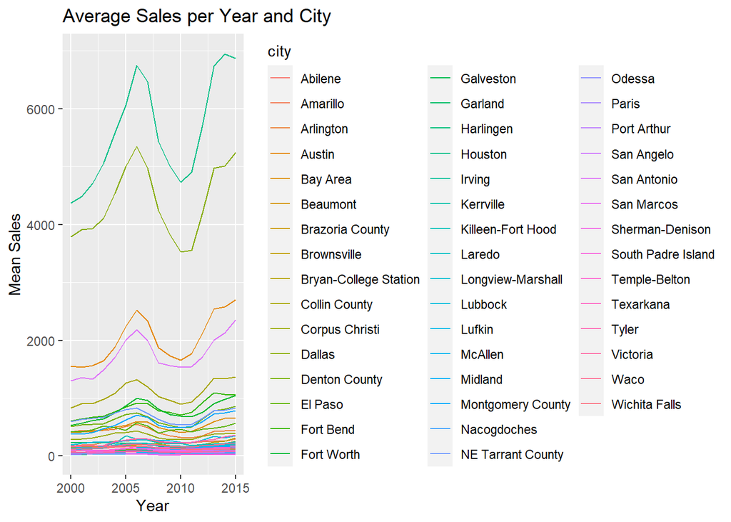

```r
ggplot(tx_city_year, aes(x = year, y = mean_sales, col = city)) +
  geom_line() +
  labs(x = "Year", y = "Mean Sales", title = "Average Sales per Year and City")
```